# Epi Machine Learning Assignment 7

Sydney Ng (uni: sn2863)

Due Tuesday March 9, 2021 by 5:30 PM

```r
mi <-
  read_csv("./mi.data.csv") %>%
  janitor::clean_names() %>%
  mutate(id = as.character(id),
         sex = as.character(case_when(sex == 0 ~ "Male",
                                      sex == 1 ~ "Female",
                                      sex == 2 ~ "Non-binary/Other")),
         pulm_adema = as.factor(pulm_adema), # levels by 0, 1 by default
         fc = factor(case_when(fc == 0 ~ "No angina pectoris",
                               fc == 1 ~ "I FC",
                               fc == 2 ~ "II FC",
                               fc == 3 ~ "III FC",
                               fc == 4 ~ "IV FC"),
                     levels = c("No angina pectoris","I FC","II FC","III FC","IV FC")),
         arr = as.factor(arr), # levels by 0, 1 by default
         diab = as.factor(diab),
         obesity = as.factor(obesity),
         asthma = as.factor(asthma),
         readmission = as.factor(readmission)
  ) %>%
  select(-id) # excluding patient id
```

# Data Preparation.

```r
#Checking for missingness and imbalance
summary(mi)
```

```
##       age            sex                sodium           alt
##  Min.   :26.00   Length:1700        Min.   :117.0   Min.   :0.0300
##  1st Qu.:54.00   Class :character   1st Qu.:133.0   1st Qu.:0.2300
##  Median :63.00   Mode  :character   Median :136.0   Median :0.3800
##  Mean   :61.87                      Mean   :136.6   Mean   :0.4736
##  3rd Qu.:70.00                      3rd Qu.:140.0   3rd Qu.:0.6100
##  Max.   :92.00                      Max.   :169.0   Max.   :3.0000
##       wbc              esr              sbp             dbp        pulm_adema
##  Min.   : 2.000   Min.   :  1.00   Min.   :  0.0   Min.   :  0.0   0:1589
##  1st Qu.: 6.400   1st Qu.:  5.00   1st Qu.:120.0   1st Qu.: 70.0   1: 111
##  Median : 8.000   Median : 10.00   Median :140.0   Median : 80.0
##  Mean   : 8.804   Mean   : 13.48   Mean   :138.8   Mean   : 82.1
##  3rd Qu.:10.500   3rd Qu.: 19.00   3rd Qu.:160.0   3rd Qu.: 90.0
##  Max.   :27.900   Max.   :140.00   Max.   :260.0   Max.   :190.0
##                   fc      arr      diab     obesity  asthma   readmission
##  No angina pectoris:682   0:1658   0:1472   0:1658   0:1662   0:1541
##  I FC              : 49   1:  42   1: 228   1:  42   1:  38   1: 159
##  II FC             :899
##  III FC            : 59
##  IV FC             : 11
##
```

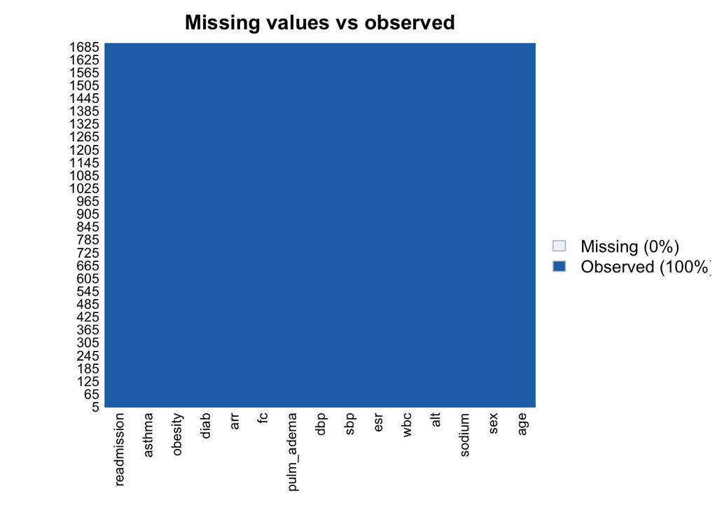

```r
missmap(mi, main = "Missing values vs observed")
```

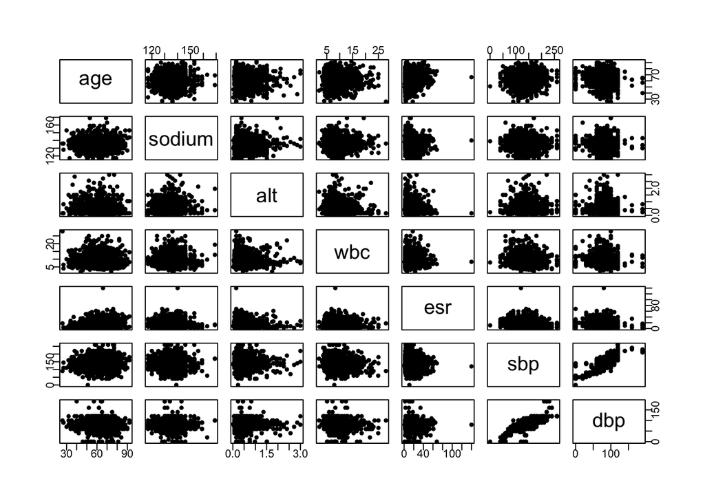

```r
#Correlations
mi_num <- mi %>% select(where(is.numeric))
mi_not_num <- mi %>% select(!where(is.numeric))

pairs(mi_num, pch = 20)
```

```r
correlations <- cor(mi_num, use="complete.obs")
high_correlations <- findCorrelation(correlations, cutoff=0.4) # caret package identifies sbp

colMeans(mi_num)
```

```
##         age      sodium         alt         wbc         esr         sbp
##  61.8705882 136.5635294   0.4735588   8.8037529  13.4764706 138.8470588
##         dbp
##  82.0970588
```

```r
apply(mi_num, 2, sd)
```

```
##        age     sodium        alt        wbc        esr        sbp        dbp
## 11.2376943  6.4934494  0.3776127  3.4440932 11.1686746 34.4855425 19.1290494
```

```r
#Centering and Scaling
set.up.preprocess <- preProcess(mi_num, method = c("center", "scale"))
#Output pre-processed values
transformed_vals <- predict(set.up.preprocess, mi_num)
mi_transformed <- bind_cols(transformed_vals, mi_not_num)
```

- There are 1700 observations and 15 features (excluding patient ID) with no missing data.
- There is a big data imbalance for `readmission` to the hospital within 30 days, our outcome of interest where 9.35% of the observations were readmitted (N = 159) and 90.65% were not readmitted (N = 1541).
- Upon visual inspection, systolic blood pressure and diastolic blood pressure (both taken at intake) are very highly linearly correlated – it would make sense to use just one of these features to reduce the feature space. All of the other numeric variables do not seem to be correlated.
- The means and standard deviations for the numeric variables in our dataset are quite different. Centering and scaling are performed, and the resulting dataset is `mi_transformed`.

**Splitting the data.**

```r
set.seed(100)
train_indices <- createDataPartition(y=mi_transformed$readmission, p=0.7, list=FALSE)
training <- mi_transformed[train_indices, ]
testing <- mi_transformed[-train_indices, ]

#Checking distribution of the outcome
training %>% group_by(readmission) %>%
  summarise(count = n(), proportion = count/nrow(training))
```

```
## # A tibble: 2 x 3
##   readmission count proportion
##   <fct>       <int>      <dbl>
## 1 0            1079     0.906
## 2 1             112     0.0940
```

```r
testing %>% group_by(readmission) %>%
  summarise(count = n(), proportion = count/nrow(testing))
```

```
## # A tibble: 2 x 3
##   readmission count proportion
##   <fct>       <int>      <dbl>
## 1 0             462     0.908
## 2 1              47     0.0923
```

# 1. Elastic Net Logistic Regression.

```r
# Regularized (elastic net) logistic regression
set.seed(100)
train_control <- trainControl(method="cv", number = 10, sampling = "up")
logistic_reg <- train(readmission ~., data = training,
                      method = "glmnet", family = "binomial",
                      trControl = train_control, tuneLength=10)
logistic_reg$bestTune
```

```
##    alpha     lambda
## 23   0.3 0.01004879
```

Up-sampling is used to address the outcome imbalance in our data. After performing a logistic regression with elastic net regularization, it turns out that the best tuning parameters for alpha and lambda are 0.3 and 0.0100488, respectively.

### Elastic net logistic regression results and predictions.

```r
# Coefficients for the regularized logistic regression
coef(logistic_reg$finalModel, logistic_reg$bestTune$lambda)
```

```
## 19 x 1 sparse Matrix of class "dgCMatrix"
##                               1
## (Intercept)         -0.60579839
## age                  0.25050217
## sodium               .
## alt                  .
## wbc                  0.17674431
## esr                 -0.01405300
## sbp                  .
## dbp                  0.25970435
## sexMale              0.15239324
## sexNon-binary/Other -1.34691953
## pulm_adema1         -0.41771938
## fcI FC              -0.08010964
## fcII FC              0.73688996
## fcIII FC             1.40351982
## fcIV FC             -2.19153127
## arr1                -0.83854909
## diab1                0.04244208
## obesity1             0.21184963
## asthma1             -0.03944416
```

```r
# Making predictions
logistic_pred <- logistic_reg %>% predict(training)

# Confusion Matrix
confusion_logistic <-
  confusionMatrix(logistic_pred, training$readmission,
                  positive = "1")
confusion_logistic$table
```

```
##           Reference
## Prediction   0   1
##          0 656  37
##          1 423  75
```

After applying this logistic regression model using regularization to the training dataset, we find that it is 61.38% accurate in predicting hospital readmission status, with a sensitivity and specificity of 66.96% and 60.8%, respectively.

# 2. Single Classification Tree.

```r
set.seed(100)
train_control <- trainControl(method="cv", number = 10, sampling = "up")
grid.singletree <- expand.grid(cp=seq(0.015, 0.050, by=0.001))

readmission_tree <- train(readmission~.,
                          data = training, method="rpart", trControl = train_control,
                          tuneGrid = grid.singletree)

readmission_tree$bestTune
```

```
##      cp
## 8 0.022
```

### Single classification tree results and predictions.

```r
varImp(readmission_tree)
```

```
## rpart variable importance
##
##                       Overall
## wbc                   100.000
## age                    93.075
## sbp                    79.886
## esr                    60.513
## fcII FC                56.609
## fcIII FC               46.568
## sodium                 30.973
## alt                    26.375
## dbp                    12.777
## pulm_adema1             6.729
## `fcIV FC`               0.000
## `fcI FC`                0.000
## `fcII FC`               0.000
## asthma1                 0.000
## arr1                    0.000
## obesity1                0.000
## diab1                   0.000
## sexMale                 0.000
## `sexNon-binary/Other`   0.000
## `fcIII FC`              0.000
```

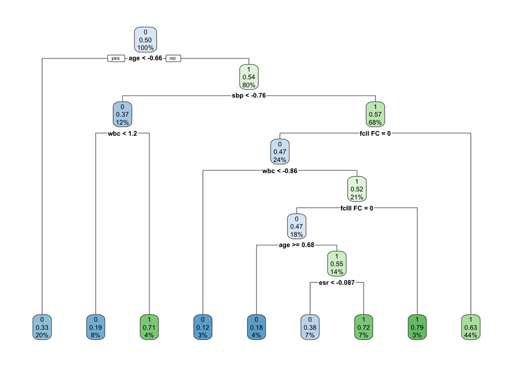

```r
rpart.plot(readmission_tree$finalModel)
```

```r
accuracy.train.singletree <-
  readmission_tree$results[which.max(readmission_tree$results[,"Accuracy"]), "Accuracy"]
```

The single classification tree identifies a complexity parameter `cp` that is equal to 0.022.

In creating the single classification tree, up-sampling was used to account for the imbalance in data. It turns out that the tree is only 60.03% accurate and can be improved upon using a random forest algorithm.

The classification tree identifies white blood cell counts `wbc`, `age`, and systolic blood pressure `sbp` to be the most important features for predicting hospital readmission within 30 days.

# 3. Random Forest.

```r
set.seed(100)
train_control <- trainControl(method="cv", number = 10, sampling = "up")
mtry.vals<-c(ncol(training)-1, sqrt(ncol(training)-1), 0.5*ncol(training)-1)

mtry.grid<-expand.grid(.mtry=mtry.vals)
rf <- train(readmission ~.,
            importance = TRUE, trControl = train_control,
            data=training, method="rf", metric="Accuracy",
            tuneGrid=mtry.grid, ntree=100)
rf$bestTune
```

```
##   mtry
## 2  6.5
```

In creating the random forest using up-sampling to account for the imbalance in data, the best tuning parameter for the number of features eligible for each split in the tree `mtry` is 6.5.

### Random forest classification results and predictions.

```r
rf$finalModel$confusion
```

```
##      0    1 class.error
## 0 1065   14  0.01297498
## 1    0 1079  0.00000000
```

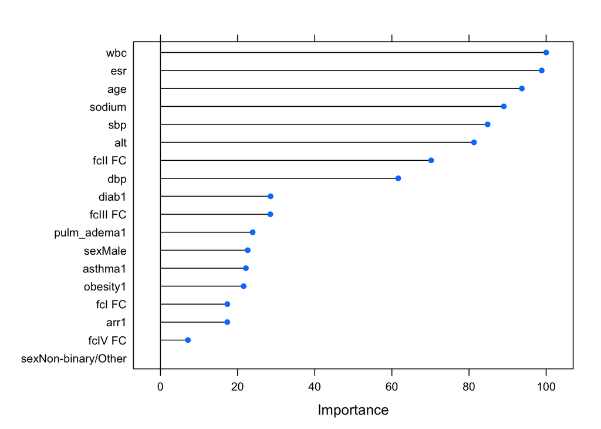

```r
# Plotting the variable importance
plot(varImp(rf))
```

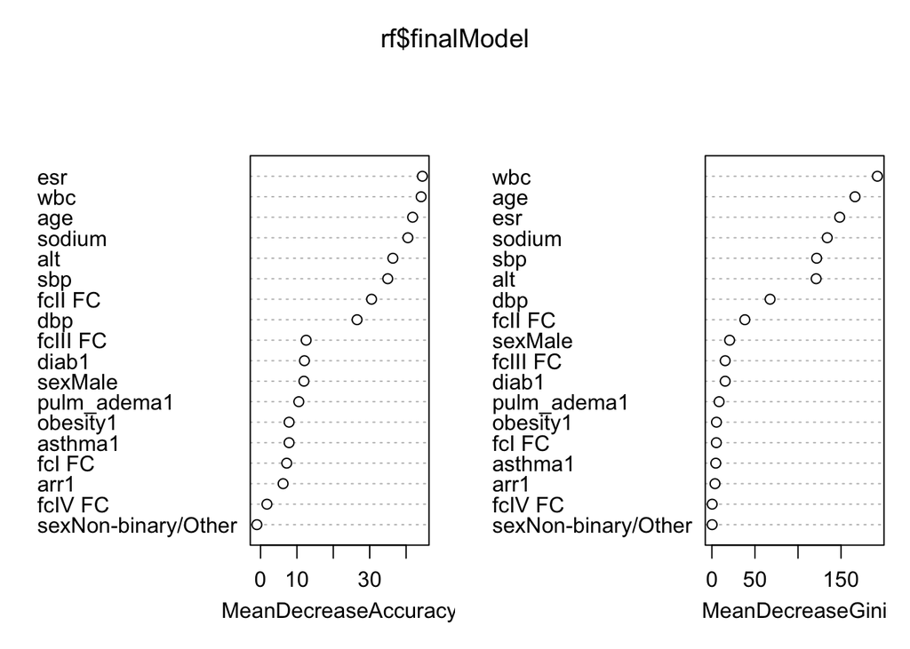

```r
varImpPlot(rf$finalModel)
```

After applying the random forest model back to the training dataset, we see it has an prediction accuracy of 99.35%.

It also identifies white blood cell counts `wbc`, `age`, and erythrocyte sedimentation rate `esr` to be the most important and influential variables in predicting hospital readmission within 30 days. The least influential variables for prediction are `arr` presence of arrhythmia, `sex` on the Non-binary/Other level, and `fcIV` functional class IV of angina pectoris in the last year.

# Final Model.

My final model is the random forest. Although it is not as interpretable as a single classification tree nor as flexible as logistic regression, the accuracy of 99.35% blows the accuracies of 61.38% and 60.03% for the logistic regression and single classification tree out of the water.

```r
# Making predictions
rf_testing <- predict(rf, testing, type="prob")
pred_binary <-
  rf_testing %>%
  select("1") %>%
  rename(Yes = "1") %>%
  mutate(classification = as.factor(ifelse(Yes > 0.5, 1, 0)))

# Printing the confusion matrix
results_test <- confusionMatrix(pred_binary$classification, testing$readmission, positive = "1")
print(results_test)
```

```
## Confusion Matrix and Statistics
##
##           Reference
## Prediction   0   1
##          0 458  47
##          1   4   0
##
##                Accuracy : 0.8998
##                  95% CI : (0.8704, 0.9245)
##     No Information Rate : 0.9077
##     P-Value [Acc > NIR] : 0.758
##
##                   Kappa : -0.0147
##
##  Mcnemar's Test P-Value : 4.074e-09
##
##             Sensitivity : 0.000000
##             Specificity : 0.991342
##          Pos Pred Value : 0.000000
##          Neg Pred Value : 0.906931
##              Prevalence : 0.092338
##          Detection Rate : 0.000000
##    Detection Prevalence : 0.007859
##       Balanced Accuracy : 0.495671
##
##        'Positive' Class : 1
##
```

After applying the random forest model to the testing dataset, we find that it is 89.98% accurate in predicting hospital readmission status, with a sensitivity and specificity of 0% and 99.13%, respectively.

Although this model is very accurate, the sensitivity is especially low. This could be another issue with the imbalance in the data where the random forest is not classifying those who truly are admitted to the hospital within 30 days accurately. This issue is also clinically significant because we would want to correctly identify those patients who are readmitted to the hospital within 30 days, because those cases of more severe myocardial infarction would probably be more likely to be readmitted after discharge.